# Análise Salarial e Profissional

Paulo Augusto

15 janeiro 2022

# Objetivos

A Nossa intenção é fazer uma análise sobre o salário da área de Data Science e sobre os contratos e níveis desta área. Falaremos sobre :

- Média Salarial
  - Média Mínima
  - Média Máxima
  - Média Salarial (Média do Mínimo e Máximo)
- Proporção de Cada Contrato com o total de Vagas
- Distribuição Salarial por Cada nível
  - Média Mínima
  - Média Máxima
  - Média Salarial (Média do Mínimo e Máximo)

  Primeiro, antes de tudo, quero que tenha noção de onde peguei as vagas, que foi do site [geek hunter](https://www.geekhunter.com.br/vagas).

## Preparaçao dos Dados

A primeira coisa que você tem que ter noção é da tabela base na qual será retirada as informações, que está nesta tabela aqui, chamada `salario`. Só será mostrado 4 linhas da tabela, para poder entender.

| Área | Vaga | Nível | Contrato | Salário.Base | Salário.Máximo | Salário.Médio |
| --- | --- | --- | --- | --- | --- | --- |
| Full-stack | Desenvolvedor(a) Full-stack PHP pleno | Junior - Pleno( ) |  | NA | NA | NA |
| Data Science | Engenheiro(a) de Dados Python | Pleno - Senior( ) | CLT | 11100 | 13000 | 12050 |
| Back-end | Desenvolvedor(a) C# pleno | Junior - Pleno( ) |  | NA | NA | NA |
| Data Science | Programador (a) de Dados Júnior / Pleno | Junior - Pleno( ) | CLT | 3000 | 5000 | 4000 |

Já que temos a intenção de fazer uma análise só sobre a área Data Science, iremos pegar, da tabela `salario` apenas as vagas que se referem a esta área. Aqui um exemplo da tabela filtrada com 5 linhas

| Área | Vaga | Nível | Contrato | Salário.Base | Salário.Máximo | Salário.Médio |
| --- | --- | --- | --- | --- | --- | --- |
| Data Science | Engenheiro(a) de Dados Python | Pleno - Senior( ) | CLT | 11100 | 13000 | 12050 |
| Data Science | Programador (a) de Dados Júnior / Pleno | Junior - Pleno( ) | CLT | 3000 | 5000 | 4000 |
| Data Science | Cientista de Dados pleno R (remoto) | Pleno - Senior( ) | PJ | 5500 | 7400 | 6450 |
| Data Science | Engenheiro(a) de Dados pleno (remoto) Python | Junior - Pleno( ) |  | NA | NA | NA |
| Data Science | Analista de Dados pleno Python | Junior - Pleno( ) | CLT | 3500 | 5000 | 4250 |

## 1 Média Salarial

Agora, nossa intenção é descobrir a média salarial mínima, máxima e média. Como foi visto antes, havia duas colunas que se referiam ao salário, o `Salário.Base` e o `Salário.Máximo`. Se for ver no site, eles dão um intervalo, que é o mínimo que você receberá caso consiga o emprego, e o máximo que pode receber. Então explicaremos essas duas colunas isoladamente, e depois criaremos uma sobre o salário médio

### 1.1 Média Salarial Mínima

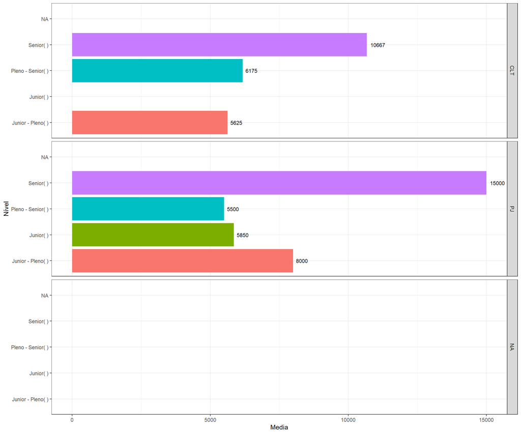

Aqui podemos ver as médias salárias mínimas para cada nível, baseada em cada contrato. Agora, vamos para a média Salarial Máxima

### 1.2 Média Salarial Máxima

Agora veremos as médias salárias máximas da área de Data Science

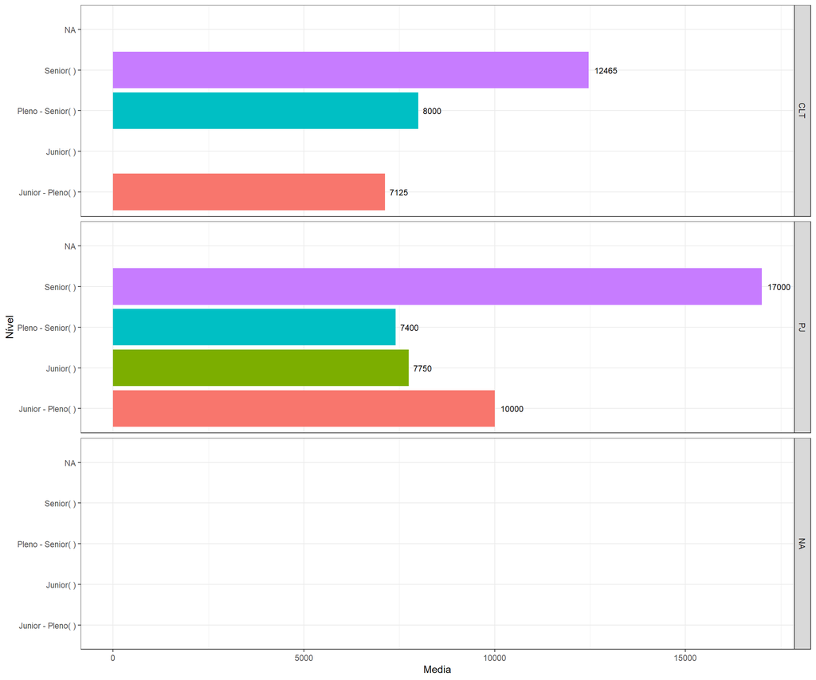

### 1.3 Média Salarial Média

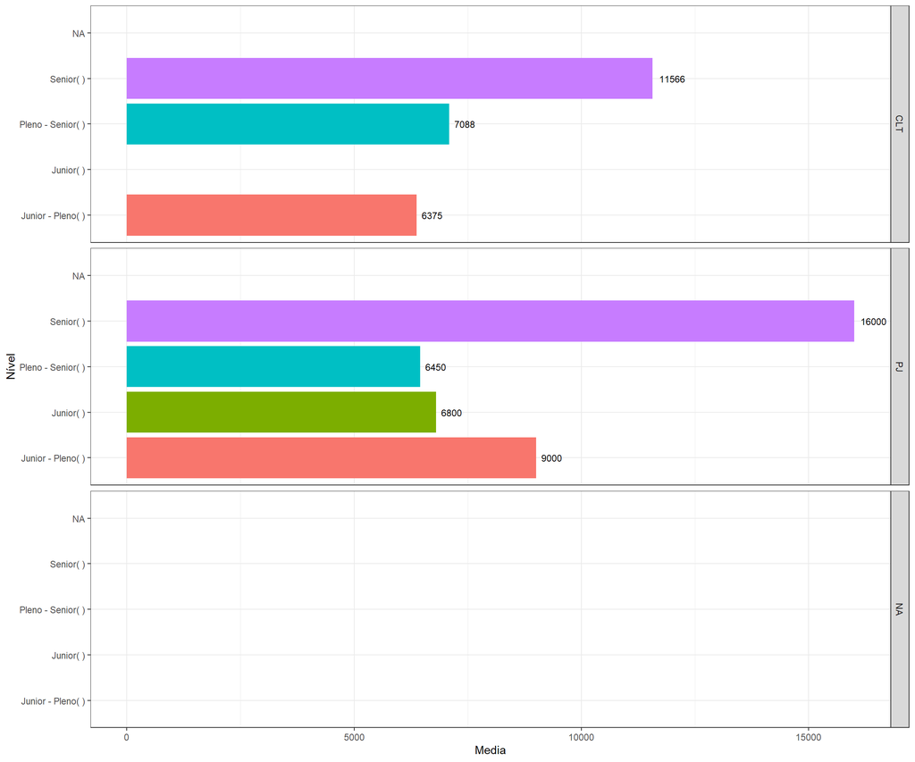

Vimos todas a Média salarial de todas as formas, na forma mínima, máxima e média. Então, agora iremos para outros tópicos.

## 2 Proporção de Cada Contrato com o total de Vagas

Agora queremos ver a proporção da quantidade de cada contrato com o total. Por exemplo, se a maioria das vagas de emprego são do Tipo CLT ou PJ.

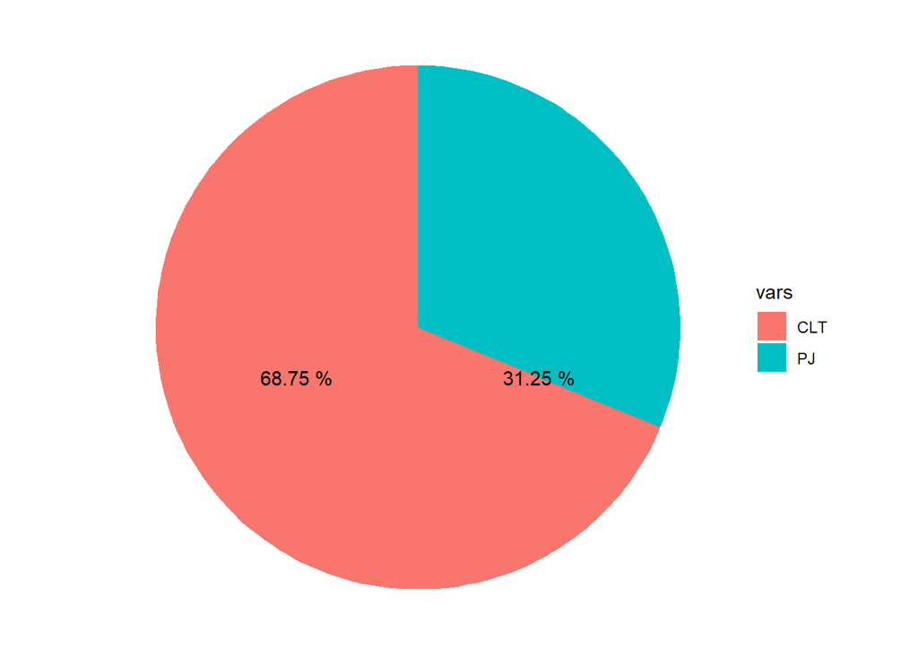

## 3 Distribuição Salarial por Cada nível

Agora que temos noção da proporção das coisas, iremos ver a distribuição salarial da área de Data Science por nível

### 3.1 Salário Mínimo

Agora queremos ter noção da distribuição Mínima. Já foi demonstrado antes mais ou menos a média, mas queremos ver de uma outra forma.

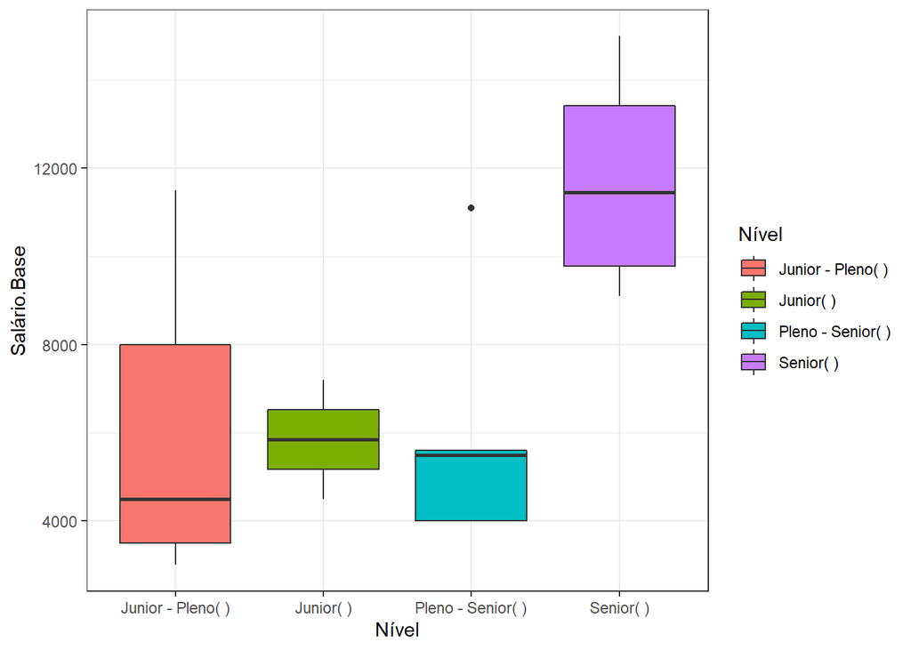

| Nível | 1° Quartil | Mediana | 3° Quartil |
| --- | --- | --- | --- |
| Junior - Pleno( ) | 3500 | 4500 | 8000 |
| Junior( ) | 5175 | 5850 | 6525 |
| Pleno - Senior( ) | 4000 | 5500 | 5600 |
| Senior( ) | 9775 | 11450 | 13425 |

Aqui podemos ver a distribuição Salarial Mínima Por cada nível dentro da tabela.

### 3.2 Salário Máximo

Agora queremos a mesma coisa que antes, mas agora, para o salário Máximo

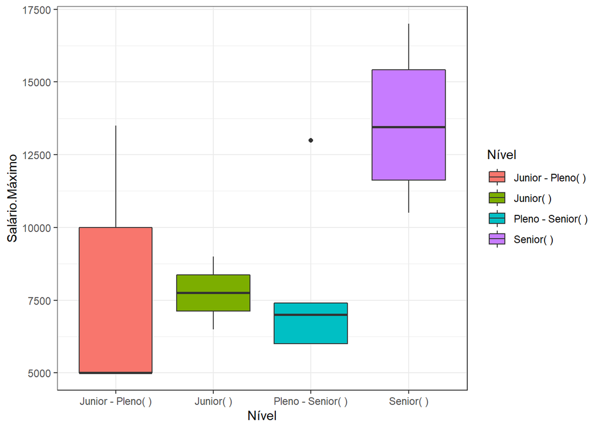

| Nível | 1° Quartil | Mediana | 3° Quartil |
| --- | --- | --- | --- |
| Junior - Pleno( ) | 5000 | 5000 | 10000.0 |
| Junior( ) | 7125 | 7750 | 8375.0 |
| Pleno - Senior( ) | 6000 | 7000 | 7400.0 |
| Senior( ) | 11625 | 13447 | 15420.5 |

Agora temos esta visão para o salário Máximo

### 3.3 Salário Médio

Agora partiremos para o salário médio

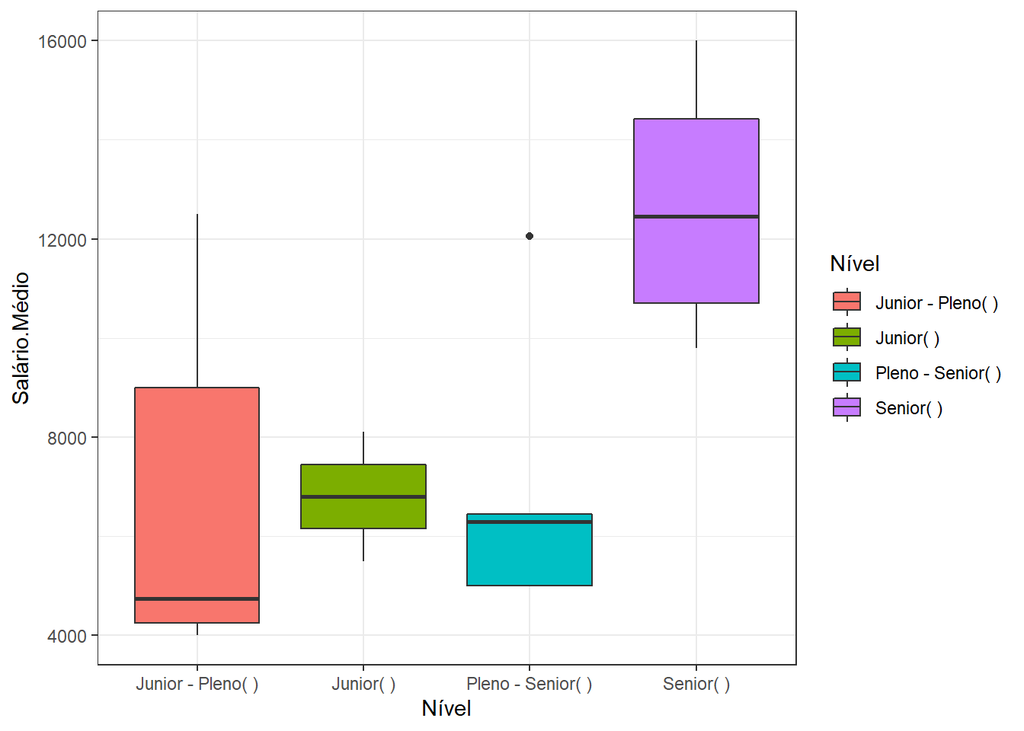

| Nível | 1° Quartil | Mediana | 3° Quartil |
| --- | --- | --- | --- |
| Junior - Pleno( ) | 4250 | 4750.0 | 9000.00 |
| Junior( ) | 6150 | 6800.0 | 7450.00 |
| Pleno - Senior( ) | 5000 | 6300.0 | 6450.00 |
| Senior( ) | 10700 | 12448.5 | 14422.75 |